# stock_out_prediction

In this project, we use a few maching learning algorithms to predict stock out for a companies *ABC*. We will explore the data first and then create new features based on existing data. Our end goal is to develop three models to predict stock out for current week, this month, and next month. We'll compare the performances of our models in the end.

- Data Source
- Data Exploration
- Developing a Model
  - Feature Engineering
- Model 1 : Predicting stock out for the current week
  - Confusion Matrix
  - Feature Importance
- Model 2 : Predicting stock out for the next 1 - 4 weeks
- Model 3 : Predicting stock out for the next 5 - 8 weeks
- Comparision of Model Performances
- Conclusion

```python
import pandas as pd
import numpy as np
import datetime
import time
import warnings
warnings.filterwarnings('ignore')

import matplotlib.pyplot as plt
%matplotlib inline
```

## Data Source

[ go back to the top ]

```python
data = pd.read_excel('data_ml_project.xlsx')
print("number of data points",len(data))
```

```
number of data points 2091
```

```python
data.columns = list(data.iloc[0])
```

```python
data.columns = ['POS', 'Channel Inventory', 'Channel Receipts', 'SO Requested',
       'SO Shipped', 'Forecast', 'PO Placed', 'PO Received', 'DC Inventory',
       'CurrentWeek', 'Week1-4', 'Week5-8']
```

```python
print("data columns are shown below: ")
data.columns
```

```
data columns are shown below:
```

```
Index(['POS', 'Channel Inventory', 'Channel Receipts', 'SO Requested',
       'SO Shipped', 'Forecast', 'PO Placed', 'PO Received', 'DC Inventory',
       'CurrentWeek', 'Week1-4', 'Week5-8'],
      dtype='object')
```

1. POS: Point of sale data. This represents the sales of TV stands in **retail stores** like Walmart, Target, etc,.
2. Channel Inventory: This represents the ending inventory of TV stands at the **retail stores**.
3. Channel Receipts: This is how many TV stands the **retailers** are receiving in any specific time period from ABC.
4. SO Requested: This is number of TV stands ordered by retailers to **ABC**
5. SO Shipped: This is the number of TV stands shipped by **ABC** to retailers. Note that this will match to "Channel Receipts" offset by a week. Week is the in transit time between ABC distribution center and retailer receiving locations. Also note that in some time periods, shipments are less than sales orders (when there is not enough inventory at ABC distribution center) and in some time periods, shipments are more than sales orders (when ABC is shipping back order goods).
6. Forecast: This is the average forecast of demand for the next several weeks as of that specific time period at **ABC**.
7. PO placed: Purchase order created by **ABC** to its supplier in China for buying TV stands.
8. PO Received: Purchase orders delivered at **ABC** distribution center from its Chinese supplier.
9. DC Inventory: Historical inventory snapshot at the end of each week at **ABC**.
10. CurrentWeek: If true, it means that a shortage has occurred at **ABC** for that week.
11. Week_1_4: If true, it means that a shortage has occurred at **ABC** for the next 1 to 4 weeks.
12. Week_5_8: If true, it means that a shortage has occurred at **ABC** for the next 5 to 8 week.

[figure not shown]

## Data Exploration

[ go back to the top ]

Note that this data is duplicated for a 4-year cycle, so we'll only look at the 1st 4 years data.

```python
data = data.iloc[1:209]  # select 1971 - 1974
df = data.reset_index()
df.columns = ["Date"] + list(data.columns)
```

```python
def lineplot(df, cols, m="o", title="?", xlabel="?", ylabel="?", xticks=None):
    '''
    line plot
    '''
    pplt = df[cols].plot(marker=m, figsize=(14, 7))
    pplt.set_title(title)
    # pplt.set_title("%s and %s of %s" % (column1, column2, ylabel))
    pplt.set_xlabel(xlabel)
    if xticks:
        pplt.set_xticks(range(len(df[xticks])))
        pplt.set_xticklabels(df[xticks])
    pplt.set_ylabel(ylabel)
    for tick in pplt.get_xticklabels():
        tick.set_rotation(45)
    return
```

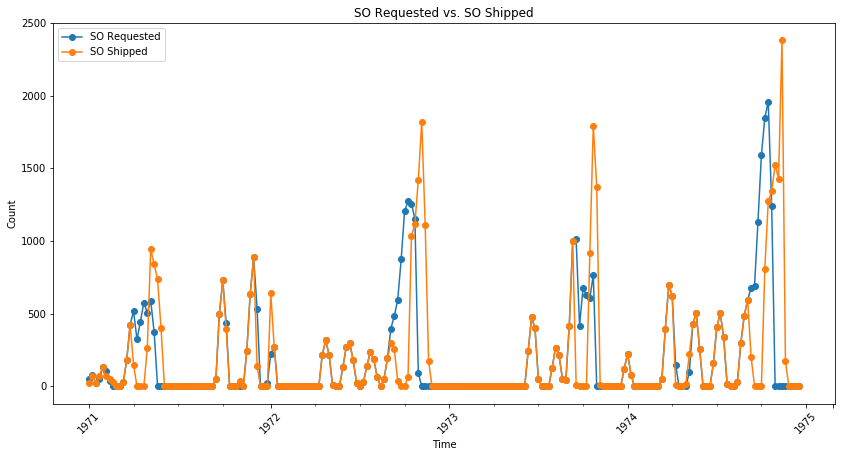

```python
temp = df.set_index("Date")
lineplot(temp, ["SO Requested","SO Shipped"], title="SO Requested vs. SO Shipped", xlabel="Time", ylabel="Count")
```

**When SO Requested > SO Shipped, a stock out happens.**

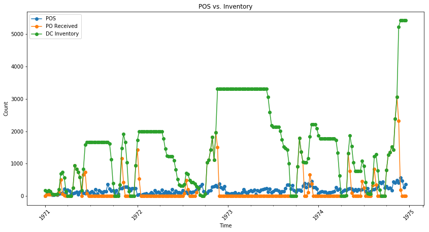

```python
temp = df.set_index("Date")
lineplot(temp, ['POS', 'PO Received', 'DC Inventory'],
         title="POS vs. Inventory", xlabel="Time", ylabel="Count")
```

Note that the magnitude of DC Inventory is much larger than PO Received and POS.

## Developing Models

[ go back to the top ]

### Feature Engineering

[ go back to the top ]

The raw data consists of the following fields.

```python
data.columns
```

```
Index(['POS', 'Channel Inventory', 'Channel Receipts', 'SO Requested',
       'SO Shipped', 'Forecast', 'PO Placed', 'PO Received', 'DC Inventory',
       'CurrentWeek', 'Week1-4', 'Week5-8'],
      dtype='object')
```

First few rows of the raw data:

```python
data[1:6]
```

|  | POS | Channel Inventory | Channel Receipts | SO Requested | SO Shipped | Forecast | PO Placed | PO Received | DC Inventory | CurrentWeek | Week1-4 | Week5-8 |
| --- | --- | --- | --- | --- | --- | --- | --- | --- | --- | --- | --- | --- |
| 1971-01-08 | 49 | 226 | 25 | 78 | 75 | 50 | 50 | 50 | 150 | True | True | True |
| 1971-01-15 | 99 | 202 | 75 | 24 | 25 | 50 | 50 | 50 | 175 | False | True | False |
| 1971-01-22 | 108 | 119 | 25 | 48 | 75 | 50 | 50 | 50 | 150 | False | True | False |
| 1971-01-29 | 33 | 161 | 75 | 131 | 131 | 50 | 131 | 50 | 69 | False | True | False |
| 1971-02-05 | 39 | 253 | 131 | 108 | 69 | 71 | 192 | 50 | 50 | True | True | False |

The current data only have information of current week, we want to add a few new features to get previous weeks info as well.

```python
## must shift 'Sales Orders', 'Shipments', 'Ending Inventory', 'POS'
## Channel Receipts = last week's shipment
for col in ['POS', 'Channel Inventory',  'Channel Receipts','SO Requested']:
    for i in range(2,6):
        temp = str(col) + "_" + str(i)
        df[temp] = df[col].shift(i)
for col in ['SO Shipped', 'Forecast', 'PO Placed', 'PO Received', 'DC Inventory']:
    for i in range(1,5):
        temp = str(col) + "_" + str(i)
        df[temp] = df[col].shift(i)

# df["POS_2"] = df["POS"].shift(2)
# df["Channel_Inventory_2"]  = df["Channel Inventory"].shift(2)
# df["Channel_Receipts_2"]  = df["Channel Receipts"].shift(2)
# df["Sales_Orders_2"]  = df["Sales Orders"].shift(2)

# df["Shipments_1"]  = df["Shipments"].shift(1)
# df["Forecast_1"]  = df["Forecast"].shift(1)
# df["PO_Placed_1"]  = df["PO Placed"].shift(1)
# df["PO_Received_1"]  = df["PO Received"].shift(1)
# df["Ending_Inventory_1"]  = df["Ending Inventory"].shift(1)

df["Shortage_week_0"] = df["CurrentWeek"].apply(lambda x: int(x == True))
df["Shortage_week_1_4"] =  df["Week1-4"].apply(lambda x: int(x == True))
df["Shortage_week_5_8"] =  df["Week5-8"].apply(lambda x: int(x == True))
```

We created a few features based on existing data fields.

```python
df.columns
```

```
Index(['Date', 'POS', 'Channel Inventory', 'Channel Receipts', 'SO Requested',
       'SO Shipped', 'Forecast', 'PO Placed', 'PO Received', 'DC Inventory',
       'CurrentWeek', 'Week1-4', 'Week5-8', 'POS_2', 'POS_3', 'POS_4', 'POS_5',
       'Channel Inventory_2', 'Channel Inventory_3', 'Channel Inventory_4',
       'Channel Inventory_5', 'Channel Receipts_2', 'Channel Receipts_3',
       'Channel Receipts_4', 'Channel Receipts_5', 'SO Requested_2',
       'SO Requested_3', 'SO Requested_4', 'SO Requested_5', 'SO Shipped_1',
       'SO Shipped_2', 'SO Shipped_3', 'SO Shipped_4', 'Forecast_1',
       'Forecast_2', 'Forecast_3', 'Forecast_4', 'PO Placed_1', 'PO Placed_2',
       'PO Placed_3', 'PO Placed_4', 'PO Received_1', 'PO Received_2',
       'PO Received_3', 'PO Received_4', 'DC Inventory_1', 'DC Inventory_2',
       'DC Inventory_3', 'DC Inventory_4', 'Shortage_week_0',
       'Shortage_week_1_4', 'Shortage_week_5_8'],
      dtype='object')
```

```python
need_cols = ['POS_2',               'POS_3',               'POS_4',
                     'POS_5', 'Channel Inventory_2', 'Channel Inventory_3',
       'Channel Inventory_4', 'Channel Inventory_5',  'Channel Receipts_2',
        'Channel Receipts_3',  'Channel Receipts_4',  'Channel Receipts_5',
            'SO Requested_2',      'SO Requested_3',      'SO Requested_4',
            'SO Requested_5',         'SO Shipped_1',         'SO Shipped_2',
               'SO Shipped_3',         'SO Shipped_4',          'Forecast_1',
                'Forecast_2',          'Forecast_3',          'Forecast_4',
               'PO Placed_1',         'PO Placed_2',         'PO Placed_3',
               'PO Placed_4',       'PO Received_1',       'PO Received_2',
             'PO Received_3',       'PO Received_4',  'DC Inventory_1',
        'DC Inventory_2',  'DC Inventory_3',  'DC Inventory_4',
            'Forecast']
avail_df = df[need_cols+['Shortage_week_0', 'Shortage_week_1_4', 'Shortage_week_5_8']].dropna()
print("number of data points",len(avail_df))
```

```
number of data points 203
```

```python
print("number of features",len(need_cols))
```

```
number of features 37
```

```python
from sklearn import datasets, linear_model
from sklearn import metrics
from sklearn.model_selection import train_test_split
from sklearn.preprocessing import StandardScaler
from sklearn.datasets import make_moons, make_circles, make_classification
from sklearn.neural_network import MLPClassifier
from sklearn.neighbors import KNeighborsClassifier
from sklearn.svm import SVC
from sklearn.gaussian_process import GaussianProcessClassifier
from sklearn.gaussian_process.kernels import RBF
from sklearn.tree import DecisionTreeClassifier
from sklearn.ensemble import RandomForestClassifier, AdaBoostClassifier
from sklearn.naive_bayes import GaussianNB
from sklearn.discriminant_analysis import QuadraticDiscriminantAnalysis
from sklearn.metrics import confusion_matrix
import itertools
```

```python
def plot_confusion_matrix(cm, classes,
                          normalize=False,
                          title='Confusion matrix',
                          cmap=plt.cm.Blues):
    """
    This function prints and plots the confusion matrix.
    Normalization can be applied by setting `normalize=True`.
    """
#     if normalize:
#         cm = cm.astype('float') / cm.sum(axis=1)[:, np.newaxis]
#         print("Normalized confusion matrix")
#     else:
#         print('Confusion matrix, without normalization')
#     print(cm)  # print matrix

    plt.imshow(cm, interpolation='nearest', cmap=cmap)
    plt.title(title)
#     plt.colorbar()
    tick_marks = np.arange(len(classes))
    plt.xticks(tick_marks, classes, rotation=45)
    plt.yticks(tick_marks, classes)

    fmt = '.2f' if normalize else 'd'
    thresh = cm.max() / 2.
    for i, j in itertools.product(range(cm.shape[0]), range(cm.shape[1])):
        plt.text(i, j, format(cm[i, j], fmt),
                 horizontalalignment="center",
                 color="white" if cm[i, j] > thresh else "black")

    plt.tight_layout()
    plt.ylabel('True label')
    plt.xlabel('Predicted label')
```

```python
h = .02  # step size in the mesh

names = ["Nearest Neighbors", "Linear SVM", "RBF SVM", "Gaussian Process",
         "Decision Tree", "Random Forest", "Neural Net", "AdaBoost",
         "Naive Bayes", "QDA"]

classifiers = [
    KNeighborsClassifier(3),
    SVC(kernel="linear", C=0.025),
    SVC(gamma=2, C=1),
    GaussianProcessClassifier(1.0 * RBF(1.0)),
    DecisionTreeClassifier(max_depth=5),
    RandomForestClassifier(max_depth=5, n_estimators=10, max_features=1),
    MLPClassifier(alpha=1),
    AdaBoostClassifier(),
    GaussianNB(),
    QuadraticDiscriminantAnalysis()]
```

## Model 1 : Predicting stock out for the current week

[ go back to the top ]

```python
X = avail_df[need_cols]
y = list(avail_df["Shortage_week_0"])
X_train, X_test, y_train, y_test = train_test_split(X, y, test_size=0.33, random_state=42)
```

```python
acc = []
prec = []
recall = []
f1 = []

for name, clf in zip(names, classifiers):
#     print(name)
    clf.fit(X_train, y_train)
    score = clf.score(X_test, y_test)
    y_pred = clf.predict(X_test)
#     print("accuracy_score")
#     print(metrics.accuracy_score(y_test, y_pred))
#     print("precision_score")
#     print(metrics.precision_score(y_test, y_pred))
#     print("recall_score")
#     print(metrics.recall_score(y_test, y_pred))
#     print("f1_score")
#     print(metrics.f1_score(y_test, y_pred))
    acc.append(metrics.accuracy_score(y_test, y_pred))
    prec.append(metrics.precision_score(y_test, y_pred))
    recall.append(metrics.recall_score(y_test, y_pred))
    f1.append(metrics.f1_score(y_test, y_pred))
#     print("")

res1 = pd.DataFrame()
res1["algorithm"] = names
res1["accuracy"] = acc
res1["precision"] = prec
res1["recall"] = recall
res1["f1"] = f1
```

```python
res1.sort_values("f1",ascending=False).round(2)
```

|  | algorithm | accuracy | precision | recall | f1 |
| --- | --- | --- | --- | --- | --- |
| 0 | Nearest Neighbors | 0.99 | 1.00 | 0.93 | 0.96 |
| 1 | Linear SVM | 0.97 | 0.93 | 0.93 | 0.93 |
| 7 | AdaBoost | 0.94 | 0.92 | 0.79 | 0.85 |
| 6 | Neural Net | 0.94 | 1.00 | 0.71 | 0.83 |
| 4 | Decision Tree | 0.91 | 0.79 | 0.79 | 0.79 |
| 5 | Random Forest | 0.93 | 1.00 | 0.64 | 0.78 |
| 8 | Naive Bayes | 0.88 | 0.64 | 1.00 | 0.78 |
| 2 | RBF SVM | 0.79 | 0.00 | 0.00 | 0.00 |
| 3 | Gaussian Process | 0.79 | 0.00 | 0.00 | 0.00 |
| 9 | QDA | 0.79 | 0.00 | 0.00 | 0.00 |

## Confusion Matrix

[ go back to the top ]

The diagram below shows the confusion matrix of the top 3 algorithms.

[figure not shown]

```python
fig = plt.figure(figsize=(14,7))
names1 = ["Nearest Neighbors", "Linear SVM",
         "AdaBoost"]
best_classifiers = [
    KNeighborsClassifier(3),
    SVC(kernel="linear", C=0.025),
    AdaBoostClassifier()]
for idx, clf in enumerate(best_classifiers):
    clf.fit(X_train, y_train)
    y_pred = clf.predict(X_test)
    cnf_matrix = confusion_matrix(y_test, y_pred)
    fig.add_subplot(int('13'+str(idx+1)))
    plot_confusion_matrix(cnf_matrix, classes=[1,0], normalize=False,
                      title=names1[idx])
plt.show()
```

## Feature Importance

[ go back to the top ]

```python
import matplotlib.cm as cm
import matplotlib.patches as mpatches
from matplotlib.legend_handler import HandlerPatch
```

```python
clf.feature_importances_ # 21, 24 highest
```

```
array([0.06, 0.04, 0.02, 0.08, 0.08, 0.08, 0.02, 0.02, 0.02, 0.  , 0.  ,
       0.  , 0.  , 0.02, 0.04, 0.  , 0.  , 0.02, 0.02, 0.02, 0.02, 0.02,
       0.02, 0.04, 0.02, 0.06, 0.  , 0.  , 0.  , 0.  , 0.  , 0.  , 0.14,
       0.04, 0.02, 0.04, 0.04])
```

```python
feature_imp = pd.DataFrame()
feature_imp["feature"] = need_cols
feature_imp["importances"] = list(clf.feature_importances_)
```

```
Text(0,0.5,'Feature')
```

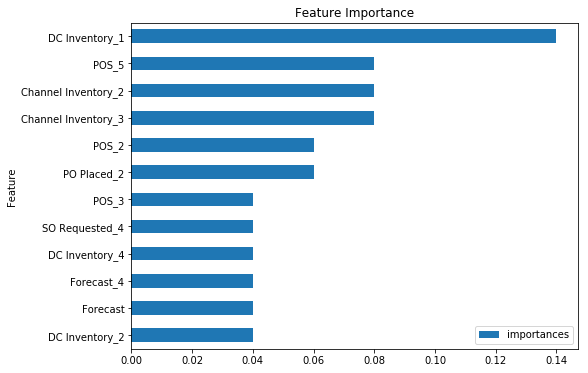

```python
pplt = feature_imp.sort_values("importances").set_index("feature")[-12:].plot(kind='barh',
                                                                       figsize=(8, 6))
pplt.set_title("Feature Importance")
pplt.set_ylabel("Value")
pplt.set_ylabel("Feature")
```

```python
# res = ["In Supply", "Stock Out"]
# plot_train = X_train.reset_index()
# plot_train["pred"] = y_train
# plot_test = X_test.reset_index()
# plot_test["pred"] = y_pred
# fig, ax = plt.subplots(figsize = (12,7))
# cmap = ["blue", "red"]

# for i, cluster in plot_train.groupby('pred'):
#         plt.scatter(cluster["Forecast_1"], cluster['Forecast_4'], edgecolors = cmap[i],
#                     label = 'Train Data %s'%(res[i]), s=30, facecolors='none')
# for i, cluster in plot_test.groupby('pred'):
#         plt.scatter(cluster["Forecast_1"], cluster['Forecast_4'], color = cmap[i],
#                     label = 'Test Data %s'%(res[i]), s=30)
# ax.set_title("Visualization of Stock Out")
# ax.set_xlabel("last week's forecast")
# ax.set_ylabel("previous 4 weeks' forecast")

# plt.legend()
```

## Model 2 : Predicting stock out for current month

[ go back to the top ]

```python
X = avail_df[need_cols]
y = list(avail_df["Shortage_week_1_4"])
X_train, X_test, y_train, y_test = train_test_split(X, y, test_size=0.33, random_state=42)

acc = []
prec = []
recall = []
f1 = []

for name, clf in zip(names, classifiers):
#     print(name)
    clf.fit(X_train, y_train)
    score = clf.score(X_test, y_test)
    y_pred = clf.predict(X_test)
#     print("accuracy_score")
#     print(metrics.accuracy_score(y_test, y_pred))
#     print("precision_score")
#     print(metrics.precision_score(y_test, y_pred))
#     print("recall_score")
#     print(metrics.recall_score(y_test, y_pred))
#     print("f1_score")
#     print(metrics.f1_score(y_test, y_pred))
    acc.append(metrics.accuracy_score(y_test, y_pred))
    prec.append(metrics.precision_score(y_test, y_pred))
    recall.append(metrics.recall_score(y_test, y_pred))
    f1.append(metrics.f1_score(y_test, y_pred))
#     print("")

res2 = pd.DataFrame()
res2["algorithm"] = names
res2["accuracy"] = acc
res2["precision"] = prec
res2["recall"] = recall
res2["f1"] = f1
```

```python
res2.sort_values("f1",ascending=False).round(2)
```

|  | algorithm | accuracy | precision | recall | f1 |
| --- | --- | --- | --- | --- | --- |
| 7 | AdaBoost | 0.88 | 0.79 | 0.79 | 0.79 |
| 0 | Nearest Neighbors | 0.81 | 0.62 | 0.79 | 0.70 |
| 4 | Decision Tree | 0.78 | 0.57 | 0.89 | 0.69 |
| 8 | Naive Bayes | 0.70 | 0.49 | 0.89 | 0.63 |
| 5 | Random Forest | 0.82 | 0.77 | 0.53 | 0.62 |
| 1 | Linear SVM | 0.78 | 0.64 | 0.47 | 0.55 |
| 6 | Neural Net | 0.67 | 0.43 | 0.53 | 0.48 |
| 9 | QDA | 0.73 | 0.56 | 0.26 | 0.36 |
| 2 | RBF SVM | 0.72 | 0.00 | 0.00 | 0.00 |
| 3 | Gaussian Process | 0.72 | 0.00 | 0.00 | 0.00 |

## Model 3 : Predicting stock out for the next month

[ go back to the top ]

```python
X = avail_df[need_cols]
y = list(avail_df["Shortage_week_5_8"])
X_train, X_test, y_train, y_test = train_test_split(X, y, test_size=0.33, random_state=42)

acc = []
prec = []
recall = []
f1 = []

for name, clf in zip(names, classifiers):
#     print(name)
    clf.fit(X_train, y_train)
    score = clf.score(X_test, y_test)
    y_pred = clf.predict(X_test)
#     print("accuracy_score")
#     print(metrics.accuracy_score(y_test, y_pred))
#     print("precision_score")
#     print(metrics.precision_score(y_test, y_pred))
#     print("recall_score")
#     print(metrics.recall_score(y_test, y_pred))
#     print("f1_score")
#     print(metrics.f1_score(y_test, y_pred))
    acc.append(metrics.accuracy_score(y_test, y_pred))
    prec.append(metrics.precision_score(y_test, y_pred))
    recall.append(metrics.recall_score(y_test, y_pred))
    f1.append(metrics.f1_score(y_test, y_pred))
#     print("")

res3 = pd.DataFrame()
res3["algorithm"] = names
res3["accuracy"] = acc
res3["precision"] = prec
res3["recall"] = recall
res3["f1"] = f1
```

```python
res3.sort_values("f1",ascending=False).round(2)
```

|  | algorithm | accuracy | precision | recall | f1 |
| --- | --- | --- | --- | --- | --- |
| 0 | Nearest Neighbors | 0.72 | 0.46 | 0.65 | 0.54 |
| 4 | Decision Tree | 0.79 | 0.62 | 0.47 | 0.53 |
| 8 | Naive Bayes | 0.57 | 0.35 | 0.82 | 0.49 |
| 5 | Random Forest | 0.75 | 0.50 | 0.47 | 0.48 |
| 9 | QDA | 0.75 | 0.50 | 0.35 | 0.41 |
| 7 | AdaBoost | 0.63 | 0.33 | 0.47 | 0.39 |
| 1 | Linear SVM | 0.69 | 0.38 | 0.35 | 0.36 |
| 6 | Neural Net | 0.61 | 0.29 | 0.35 | 0.32 |
| 2 | RBF SVM | 0.75 | 0.00 | 0.00 | 0.00 |
| 3 | Gaussian Process | 0.75 | 0.00 | 0.00 | 0.00 |

## Comparision of Model Performances

[ go back to the top ]

```python
comparison = pd.concat([res1.sort_values("f1",ascending=False)[:3],
                        res2.sort_values("f1",ascending=False)[:3],
                        res3.sort_values("f1",ascending=False)[:3]] )
comparison["model"] = ["1_current week", "1_current week", "1_current week",
                       "2_current month", "2_current month", "2_current month",
                       "3_next month", "3_next month", "3_next month"]
comparison["top"] = ["top1", "top2", "top3",
                     "top1", "top2", "top3",
                     "top1", "top2", "top3"]
```

```python
table = pd.pivot_table(comparison[["model", "f1", "top"]],
                       values='f1', index=['model'], columns=['top'] )
```

```
Text(0,0.5,'F1 Score')
```

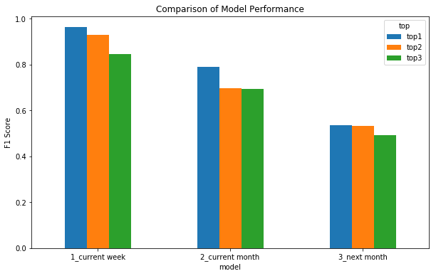

```python
pplt = table.plot(kind="bar",figsize=(10, 6), rot=0)
pplt.set_title("Comparison of Model Performance")
pplt.set_ylabel("F1 Score")
```

## Conclusion

[ go back to the top ]

In this project, we built three machine learning models to predict stock out for current, next 1-4 and next 5-8 week and compared the model performances between the best classifiers of these three models. It is clear that we could obtain high accuracy (99%) when predicting current week out of stock items, and the accuracy drops for the models used to predict current month and next month, which make sense as there are more uncertainties in the future.